# SNAProjectNetflixPrize

```r
upm_edges <- get.edgelist(upm)
n_of_edges <- nrow(upm_edges) #total number of edges

year_diffs <- numeric(n_of_edges)
for (i in 1:n_of_edges) {
  m_id1 <- as.numeric(upm_edges[i, 1])
  m_id2 <- as.numeric(upm_edges[i, 2])
  year_diffs[i] <- abs(movies[movies$movie_id == m_id1, "year_of_release"]
                             - movies[movies$movie_id == m_id2, "year_of_release"])
}
mean(year_diffs) #mean(abs(u1$year - u2$year))
```

```
## [1] 19.72623
```

```r
sd(year_diffs)
```

```
## [1] 14.89654
```

#The actual year difference among neighbours is lower than the theorical difference but not very significantly

```r
#Now let's compare the variance of the years of release in the whole dataframe with the variance in the single clusters

year_variance <- numeric(length(unique(movies$clustering_membership)))
print(var(movies$year_of_release))
```

```
## [1] 327.9071
```

```r
for (i in unique(movies$clustering_membership)) {
  year_variance[i] <- var(movies$year_of_release[movies$clustering_membership == i])
}
print(year_variance)
```

```
## [1] 360.9926 159.4667 101.7000
```

```r
print(mean(year_variance))
```

```
## [1] 207.3864
```

```r
print(sd(year_variance))
```

```
## [1] 136.1264
```

#We notice that the cluster have on average a quite smaller variance (with the exception of the first cluster)

```r
#Let's see the average year of each cluster
year_mean <- numeric(length(unique(movies$clustering_membership)))
print(mean(movies$year_of_release))
```

```
## [1] 1978.875
```

```r
for (i in unique(movies$clustering_membership)) {
  year_mean[i] <- mean(movies$year_of_release[movies$clustering_membership == i])
}
print(year_mean)
```

```
## [1] 1979.276 1988.333 1965.200
```

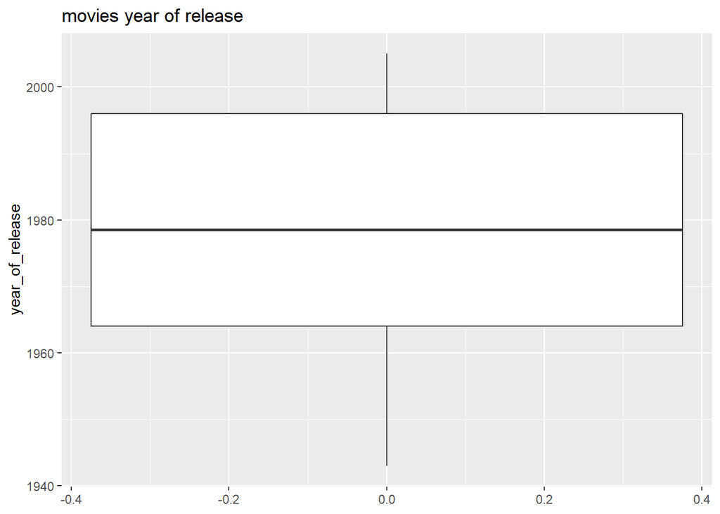

```r
ggplot(movies, aes(y=year_of_release)) +
  geom_boxplot() +
  ggtitle("movies year of release")
```

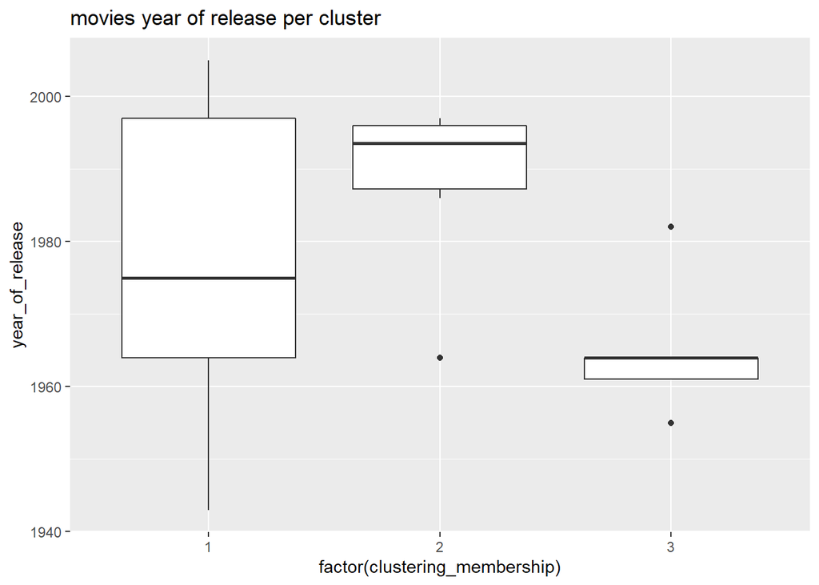

```r
ggplot(movies, aes(x=factor(clustering_membership), y=year_of_release)) +
  geom_boxplot() +
  ggtitle("movies year of release per cluster")
```

#Homophily among movies of the same genre

```r
genres <- unique(movies$genre)
n_of_nodes_per_genre <- numeric(length(genres))
for (i in 1:length(genres)){
  n_of_nodes_per_genre[i] <- nrow(movies[movies$genre == genres[i], ])
}
```

```r
#Similarly to what we did for the year of release we want to compare:
# - the probability p of a random edge to link 2 movies of the same genre if the graph was random
# - the actual probability d of a random edge to link 2 movies of the same genre
p = 0
for (i in 1:length(genres)){
  p = p + (n_of_nodes_per_genre[i]/n_of_nodes) * ((n_of_nodes_per_genre[i]-1)/n_of_nodes)
}
p # probability of a random edge to link 2 movies of the same genre if the graph was random
```

```
## [1] 0.1425
```

```r
d = 0
for (i in 1:length(genres)){
  d = d + sum((as.numeric(upm_edges[, 1]) %in% movies[movies$genre == genres[i], "movie_id"]) & (as.numeric(upm_edges[, 2]) %in% movies[movies$genre == genres[i], "movie_id"])) / n_of_edges
}
d # actual probability of a random edge to link 2 movies of the same genre
```

```
## [1] 0.1459016
```

#the number of links among movies of the same genre is slightly greater than the expected number, but not significantly so

```r
d_per_cluster <- numeric(length(unique(movies$clustering_membership)))
for (i in unique(movies$clustering_membership)) {
  d_per_cluster[i] <- 0
  nodes_in_cluster <- movies[movies$clustering_membership == i,]
  n_of_nodes_in_cluster <- nrow(nodes_in_cluster)
  for (n in nodes_in_cluster$movie_id){
    for (m in nodes_in_cluster$movie_id) {
      if (m != n & movies[movies$movie_id == m, "genre"] == movies[movies$movie_id == n, "genre"]) {
        d_per_cluster[i] <- d_per_cluster[i] + 1
      }
    }
  }
  d_per_cluster[i] <- d_per_cluster[i]/n_of_nodes_in_cluster/(n_of_nodes_in_cluster-1)
}
d_per_cluster
```

```
## [1] 0.14532020 0.06666667 0.20000000
```

```r
mean(d_per_cluster)
```

```
## [1] 0.137329
```

#On average we notice that the movies that end up in the same cluster are not more likely to be of the same genre. #We can thereby conclude that there is no evidence of homophily per genre among movies